# Homework 03

## Question 1: Build an `explain-to-me` skill

I created `explain-to-me/SKILL.md`, validated it, and installed it in my Codex skills directory. I tested it with the prompt, “Use `explain-to-me` to read and explain Question 2.” It restated the goal, listed the simulation outputs, clarified that the same fixed design and noise pair must be reused across penalty values, and pointed to the ridge-regression lecture. It did not calculate results or write solution code, so I kept the skill.

The complete skill file is included at the end of this report.

## Question 2: Ridge regression with nearly collinear predictors

### Part a

I generated and standardized the design once using the population standard deviation, which makes the average squared value of each centered column equal to one.

**Show the Python workflow**

```python
rng = np.random.default_rng(43231)
n = 100

L, U1, U2, X3, X4 = rng.standard_normal((5, n))
X = np.column_stack(
    (L + 0.04 * U1, L + 0.04 * U2, X3, X4)
)
X = (X - X.mean(axis=0)) / X.std(axis=0, ddof=0)

corr_12 = np.corrcoef(X[:, 0], X[:, 1])[0, 1]
singular_values_q2 = np.linalg.svd(X, compute_uv=False)

pd.DataFrame(
    {
        "quantity": ["cor(X1, X2)", "largest singular value", "smallest singular value"],
        "value": [corr_12, singular_values_q2.max(), singular_values_q2.min()],
    }
).style.format({"value": "{:.4f}"})
```

|  | quantity | value |
| --- | --- | --- |
| 0 | cor(X1, X2) | 0.9983 |
| 1 | largest singular value | 14.1730 |
| 2 | smallest singular value | 0.4061 |

The first two columns are almost the same. The sum direction is therefore well represented in the data, while the difference direction is close to a null direction. Noise is strongly amplified when estimating a coefficient component in a direction with a small singular value. This makes $\widehat\beta_1-\widehat\beta_2$ much more variable than $\widehat\beta_1+\widehat\beta_2$.

### Part b

For each repetition, I generated one training response and one independent test response and reused that pair for all three values of $\lambda$.

**Show the Python workflow**

```python
beta_true = np.array([1.5, 1.5, 1.0, 0.0])
mu = X @ beta_true
lambdas_q2 = [0.0, 0.02, 0.2]
records = []

for rep in range(200):
    y = mu + rng.standard_normal(n)
    y_test = mu + rng.standard_normal(n)

    for lam in lambdas_q2:
        intercept, beta_hat = ridge_fit(X, y, lam)
        records.append(
            {
                "rep": rep,
                "lambda": lam,
                "beta1": beta_hat[0],
                "beta2": beta_hat[1],
                "sum": beta_hat[0] + beta_hat[1],
                "difference": beta_hat[0] - beta_hat[1],
                "train_mse": np.mean((y - intercept - X @ beta_hat) ** 2),
                "test_mse": np.mean((y_test - intercept - X @ beta_hat) ** 2),
            }
        )

q2_results = pd.DataFrame(records)
q2_summary = q2_results.groupby("lambda").agg(
    beta1_mean=("beta1", "mean"),
    beta1_sd=("beta1", "std"),
    beta2_mean=("beta2", "mean"),
    beta2_sd=("beta2", "std"),
    sum_mean=("sum", "mean"),
    sum_sd=("sum", "std"),
    diff_mean=("difference", "mean"),
    diff_sd=("difference", "std"),
    train_mse=("train_mse", "mean"),
    test_mse=("test_mse", "mean"),
).reset_index()

q2_table = pd.DataFrame(
    {
        "lambda": q2_summary["lambda"],
        "beta1: mean (SD)": [
            f"{m:.3f} ({s:.3f})"
            for m, s in zip(q2_summary["beta1_mean"], q2_summary["beta1_sd"])
        ],
        "beta2: mean (SD)": [
            f"{m:.3f} ({s:.3f})"
            for m, s in zip(q2_summary["beta2_mean"], q2_summary["beta2_sd"])
        ],
        "sum: mean (SD)": [
            f"{m:.3f} ({s:.3f})"
            for m, s in zip(q2_summary["sum_mean"], q2_summary["sum_sd"])
        ],
        "difference: mean (SD)": [
            f"{m:.3f} ({s:.3f})"
            for m, s in zip(q2_summary["diff_mean"], q2_summary["diff_sd"])
        ],
        "average train MSE": q2_summary["train_mse"],
        "average test MSE": q2_summary["test_mse"],
    }
)
q2_table.style.format(
    {"lambda": "{:.2f}", "average train MSE": "{:.3f}", "average test MSE": "{:.3f}"}
)
```

|  | lambda | beta1: mean (SD) | beta2: mean (SD) | sum: mean (SD) | difference: mean (SD) | average train MSE | average test MSE |
| --- | --- | --- | --- | --- | --- | --- | --- |
| 0 | 0.00 | 1.290 (1.795) | 1.701 (1.798) | 2.992 (0.105) | -0.411 (3.592) | 0.949 | 1.038 |
| 1 | 0.02 | 1.465 (0.145) | 1.497 (0.148) | 2.961 (0.104) | -0.032 (0.274) | 0.960 | 1.029 |
| 2 | 0.20 | 1.355 (0.049) | 1.359 (0.050) | 2.715 (0.095) | -0.004 (0.029) | 1.064 | 1.125 |

### Part c

OLS is approximately unbiased across repeated samples, but it has very high variance for the two individual coefficients. In particular, the standard deviation of the coefficient difference is about 3.59 even though the true difference is zero. With $\lambda=0.02$, both individual standard deviations fall to about 0.15 and the average test MSE decreases slightly. The small penalty adds a little bias but removes much more variance.

The larger penalty, $\lambda=0.2$, is even more stable, but it shrinks the coefficient sum away from its true value of 3. That extra bias raises both training and test MSE. The fitted values do not change as dramatically as the individual coefficients because $X_1$ and $X_2$ are nearly identical: moving one coefficient up and the other down changes the coefficient difference a lot but has little effect on $X_1\widehat\beta_1+X_2\widehat\beta_2$.

## Question 3: What does ridge regression shrink?

### Part a

Differentiating the objective gives

$$\nabla L_\lambda(\boldsymbol\beta)
=
-\frac{1}{n}\mathbf X^{\mathsf T}
(\widetilde{\mathbf y}-\mathbf X\boldsymbol\beta)
+\lambda\boldsymbol\beta.$$

Setting this gradient equal to zero and multiplying by $n$ gives

$$(\mathbf X^{\mathsf T}\mathbf X+n\lambda\mathbf I_p)
\widehat{\boldsymbol\beta}_\lambda
=\mathbf X^{\mathsf T}\widetilde{\mathbf y}.$$

For any nonzero vector $\mathbf z$ and $\lambda>0$,

$$\mathbf z^{\mathsf T}
(\mathbf X^{\mathsf T}\mathbf X+n\lambda\mathbf I_p)\mathbf z
=\lVert\mathbf X\mathbf z\rVert_2^2+n\lambda\lVert\mathbf z\rVert_2^2>0.$$

Thus the matrix is positive definite and invertible, even when $\mathbf X$ is rank deficient or $p>n$, so the solution is unique.

### Part b

Using the compact SVD in the normal equation,

$$\widehat{\boldsymbol\beta}_\lambda
=\mathbf V_r
\operatorname{diag}\left(\frac{d_j}{d_j^2+n\lambda}\right)
\mathbf U_r^{\mathsf T}\widetilde{\mathbf y}.$$

Multiplying by $\mathbf X$ gives the fitted centered response

$$\widehat{\mathbf y}_\lambda
=\mathbf U_r
\operatorname{diag}\left(\frac{d_j^2}{d_j^2+n\lambda}\right)
\mathbf U_r^{\mathsf T}\widetilde{\mathbf y}.$$

Therefore the component in direction $\mathbf u_j$ is multiplied by $\rho_j(\lambda)=d_j^2/(d_j^2+n\lambda)$.

Here $n\lambda=1$, so

**Show the Python workflow**

```python
d = np.array([10.0, 2.0, 0.2])
rho = d**2 / (d**2 + 100 * 0.01)
pd.DataFrame(
    {"direction": [1, 2, 3], "d_j": d, "rho_j": rho}
).style.format({"d_j": "{:.1f}", "rho_j": "{:.4f}"})
```

|  | direction | d_j | rho_j |
| --- | --- | --- | --- |
| 0 | 1 | 10.0 | 0.9901 |
| 1 | 2 | 2.0 | 0.8000 |
| 2 | 3 | 0.2 | 0.0385 |

The effective degrees of freedom, including the intercept, are

$$1+0.9901+0.8000+0.0385=2.8286.$$

### Part c

The third direction receives the strongest shrinkage because it has the smallest singular value. Data contain little information in this direction, so an unpenalized estimate would amplify noise and have high prediction variance. Shrinking it reduces that variance. The cost could be substantial prediction bias if the true mean response has a large component along $\mathbf u_3$.

## Question 4: Ridge regression and optimization

### Part a

The unpenalized condition number is

$$\kappa(\mathbf A_0)=\frac{9}{0.01}=900.$$

Adding $\lambda=0.09$ changes the eigenvalues to $9.09$ and $0.10$, so

$$\kappa(\mathbf A_\lambda)=\frac{9.09}{0.10}=90.9.$$

The ridge objective is much less elongated: its formerly flat direction now has more curvature, although the two directions are still not equally curved.

### Part b

Since the Hessian is $\mathbf A_\lambda$, subtracting the minimizer from the gradient-descent update gives

$$\mathbf e^{(k+1)}
=(\mathbf I-\eta\mathbf A_\lambda)\mathbf e^{(k)}.$$

An eigenvector of $\mathbf A_0$ with eigenvalue $a$ is an eigenvector of $\mathbf A_\lambda$ with eigenvalue $a+\lambda$. Its error component is therefore multiplied by $1-\eta(a+\lambda)$ at each step.

Every direction contracts when

$$|1-\eta(a+\lambda)|<1
\quad\text{for both eigenvalues},$$

which here requires

$$0<\eta<\frac{2}{9.09}\approx 0.2200.$$

For $\eta=1/M=1/9.09$, the contraction factors for eigenvalues $9.09$ and $0.10$ are

$$1-\frac{9.09}{9.09}=0,
\qquad
1-\frac{0.10}{9.09}\approx0.9890.$$

The high-curvature direction reaches its optimum immediately, while the low-curvature direction converges slowly. For $\eta=2.1/M$, the factor in the $M$ direction is $1-2.1=-1.1$. Its magnitude exceeds one, so the assumed nonzero error component grows with alternating sign and the method does not converge.

### Part c

Choosing $\lambda$ only for fast optimization ignores the statistical target. A larger penalty improves conditioning but also changes the estimator and can add prediction bias. Penalty selection should be based on estimated out-of-sample performance, such as cross-validation or GCV, rather than the number of gradient steps.

## Question 5: Selecting the ridge penalty for real-estate prediction

**Show the Python workflow**

```python
realestate = pd.read_csv("data/realestate.csv")
split_folds = pd.read_csv("data/realestate-split-folds.csv")
all_data = realestate.merge(split_folds, on="row_id", validate="one_to_one")

predictors = ["date", "age", "distance", "stores", "latitude", "longitude"]
train = all_data.loc[all_data["split"] == "train"].copy()
test = all_data.loc[all_data["split"] == "test"].copy()
lambda_grid = np.r_[0.0, 10.0 ** (-4 + 0.05 * np.arange(121))]

len(train), len(test)
```

```
(332, 82)
```

### Part a

Within each fold, I estimated predictor means and scales only from the other nine folds. I also centered the fitting responses and used their mean as the unpenalized intercept.

**Show the Python workflow**

```python
fold_errors = np.empty((10, len(lambda_grid)))

for fold in range(1, 11):
    fitting = train.loc[train["cv_fold"] != fold]
    validation = train.loc[train["cv_fold"] == fold]

    means = fitting[predictors].mean().to_numpy()
    scales = fitting[predictors].std(ddof=0).to_numpy()
    X_fit = (fitting[predictors].to_numpy() - means) / scales
    X_val = (validation[predictors].to_numpy() - means) / scales
    y_fit = fitting["price"].to_numpy()
    y_val = validation["price"].to_numpy()

    for j, lam in enumerate(lambda_grid):
        intercept, beta_hat = ridge_fit(X_fit, y_fit, lam)
        predictions = intercept + X_val @ beta_hat
        fold_errors[fold - 1, j] = np.mean((y_val - predictions) ** 2)

cv_mean = fold_errors.mean(axis=0)
cv_se = fold_errors.std(axis=0, ddof=1) / np.sqrt(10)
min_idx = np.argmin(cv_mean)
lambda_min = lambda_grid[min_idx]
one_se_limit = cv_mean[min_idx] + cv_se[min_idx]
one_se_idx = np.flatnonzero(cv_mean <= one_se_limit)[-1]
lambda_1se = lambda_grid[one_se_idx]

pd.DataFrame(
    {
        "choice": ["lambda_min", "lambda_1se"],
        "lambda": [lambda_min, lambda_1se],
        "mean CV MSE": [cv_mean[min_idx], cv_mean[one_se_idx]],
        "SE": [cv_se[min_idx], cv_se[one_se_idx]],
    }
).style.format({"lambda": "{:.6f}", "mean CV MSE": "{:.3f}", "SE": "{:.3f}"})
```

|  | choice | lambda | mean CV MSE | SE |
| --- | --- | --- | --- | --- |
| 0 | lambda_min | 0.019953 | 82.978 | 19.230 |
| 1 | lambda_1se | 1.584893 | 101.596 | 19.977 |

The minimum CV error is 82.978 with SE 19.230, so the one-standard-error cutoff is 102.208. The largest grid value below that cutoff is $\lambda_{\mathrm{1se}}=1.584893$.

**Show the Python workflow**

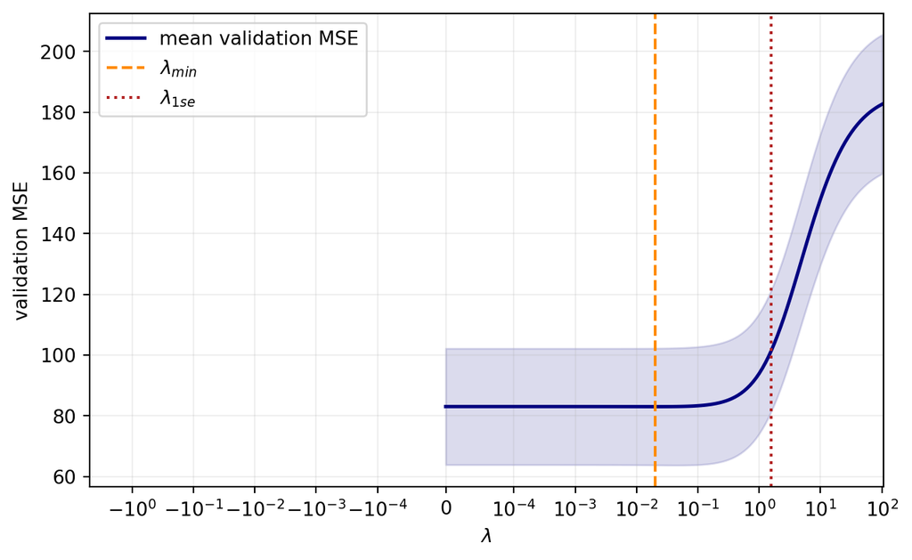

```python
fig, ax = plt.subplots(figsize=(7.5, 4.5))
ax.plot(lambda_grid, cv_mean, color="navy", lw=1.8, label="mean validation MSE")
ax.fill_between(lambda_grid, cv_mean - cv_se, cv_mean + cv_se, color="navy", alpha=0.14)
ax.axvline(lambda_min, color="darkorange", ls="--", label=r"$\lambda_{min}$")
ax.axvline(lambda_1se, color="firebrick", ls=":", label=r"$\lambda_{1se}$")
ax.set_xscale("symlog", linthresh=1e-4)
ax.set_xlabel(r"$\lambda$")
ax.set_ylabel("validation MSE")
ax.legend()
ax.grid(alpha=0.2)
plt.show()
```

### Part b

For GCV, I estimated the predictor means and scales once from all 332 training observations. If $d_j$ are the singular values of this standardized training matrix, then

$$\operatorname{df}_{\mathrm{eff}}(\lambda)
=1+\sum_j\frac{d_j^2}{d_j^2+n\lambda}.$$

**Show the Python workflow**

```python
means = train[predictors].mean().to_numpy()
scales = train[predictors].std(ddof=0).to_numpy()
X_train = (train[predictors].to_numpy() - means) / scales
y_train = train["price"].to_numpy()
y_bar = y_train.mean()
singular_values = np.linalg.svd(X_train, compute_uv=False)

train_mse_grid = np.empty(len(lambda_grid))
df_grid = np.empty(len(lambda_grid))
gcv = np.empty(len(lambda_grid))

for j, lam in enumerate(lambda_grid):
    intercept, beta_hat = ridge_fit(X_train, y_train, lam)
    fitted = intercept + X_train @ beta_hat
    train_mse_grid[j] = np.mean((y_train - fitted) ** 2)
    df_grid[j] = 1 + np.sum(
        singular_values**2 / (singular_values**2 + len(train) * lam)
    )
    gcv[j] = train_mse_grid[j] / (1 - df_grid[j] / len(train)) ** 2

gcv_idx = np.argmin(gcv)
lambda_gcv = lambda_grid[gcv_idx]

pd.DataFrame(
    {"lambda_GCV": [lambda_gcv], "minimum GCV": [gcv[gcv_idx]]}
).style.format({"lambda_GCV": "{:.6f}", "minimum GCV": "{:.3f}"})
```

|  | lambda_GCV | minimum GCV |
| --- | --- | --- |
| 0 | 0.028184 | 83.502 |

**Show the Python workflow**

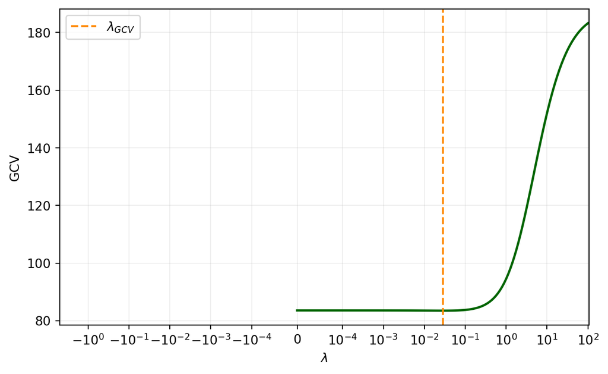

Figure 2: GCV over the supplied penalty grid.

```python
fig, ax = plt.subplots(figsize=(7.5, 4.5))
ax.plot(lambda_grid, gcv, color="darkgreen", lw=1.8)
ax.axvline(lambda_gcv, color="darkorange", ls="--", label=r"$\lambda_{GCV}$")
ax.set_xscale("symlog", linthresh=1e-4)
ax.set_xlabel(r"$\lambda$")
ax.set_ylabel("GCV")
ax.legend()
ax.grid(alpha=0.2)
plt.show()
```

The GCV choice is $\lambda_{\mathrm{GCV}}=0.028184$, close to the ten-fold CV minimum.

### Part c

Only after fixing the three penalty choices above, I standardized the test predictors using the full-training means and scales and evaluated the test responses.

**Show the Python workflow**

```python
X_test = (test[predictors].to_numpy() - means) / scales
y_test = test["price"].to_numpy()

names = ["OLS", "lambda_min", "lambda_1se", "lambda_GCV"]
chosen_lambdas = [0.0, lambda_min, lambda_1se, lambda_gcv]
final_records = []

for name, lam in zip(names, chosen_lambdas):
    intercept, beta_hat = ridge_fit(X_train, y_train, lam)
    train_predictions = intercept + X_train @ beta_hat
    test_predictions = intercept + X_test @ beta_hat
    df_eff = 1 + np.sum(
        singular_values**2 / (singular_values**2 + len(train) * lam)
    )
    final_records.append(
        {
            "model": name,
            "lambda": lam,
            "training MSE": np.mean((y_train - train_predictions) ** 2),
            "test MSE": np.mean((y_test - test_predictions) ** 2),
            "effective df": df_eff,
        }
    )

pd.DataFrame(final_records).style.format(
    {"lambda": "{:.6f}", "training MSE": "{:.3f}", "test MSE": "{:.3f}", "effective df": "{:.3f}"}
)
```

|  | model | lambda | training MSE | test MSE | effective df |
| --- | --- | --- | --- | --- | --- |
| 0 | OLS | 0.000000 | 80.094 | 66.322 | 7.000 |
| 1 | lambda_min | 0.019953 | 80.135 | 66.000 | 6.773 |
| 2 | lambda_1se | 1.584893 | 100.374 | 81.200 | 3.033 |
| 3 | lambda_GCV | 0.028184 | 80.171 | 65.903 | 6.689 |

The two mild ridge fits have almost the same training and test errors as OLS, with a small reduction in effective degrees of freedom. The one-standard-error fit is much more strongly regularized: its effective degrees of freedom fall to about 3.03, but both its training and test errors are higher. In this split, GCV happens to have the smallest test MSE, but the difference from $\lambda_{\min}$ and OLS is small.

The final test set is for estimating performance after model selection. Choosing whichever row has the smallest observed test MSE would use test outcomes to tune the model, making the reported test performance optimistically biased. The penalty choice must remain the one fixed by CV or GCV before viewing this table.

## `explain-to-me` skill

```yaml
---
name: explain-to-me
description: Explain a STAT 432 homework question when the student explicitly asks, without solving it.
---

# Explain to Me

Help me understand the assigned question before I try it.

- Restate the question's goal in plain language.
- List the work and outputs the question requires.
- Clarify important notation or constraints, but do not calculate results, write solution code, or complete the answer.
- Point me to the most relevant section of [Ridge Regression: Stability Through Shrinkage](https://teazrq.github.io/stat432rpy/topics/ridge-regression/ridge-regression.html) or [From a Penalized Objective to a Fitted Ridge Model](https://teazrq.github.io/stat432rpy/topics/ridge-regression/optimization-and-cross-validation.html).
- End with one short check-for-understanding question.
```